# Red and Purple Urchins

Alissa Patterson

10/28/2021

## Overview

### This code wrangles, analyses, and visualizes data on red and purple urchins recorded by Santa Barbara Coastal Long Term Ecological Research program divers.

Data: Reed, D. 2020. SBC LTER: Reef: Long-term experiment: Kelp removal: Urchin size frequency distribution ver 20. Environmental Data Initiative. https://doi.org/10.6073/pasta/5a1e9ef03aa47bd2225c0bb98a02a63b.

## Attach packages

```r
knitr::opts_chunk$set(echo = TRUE, message = FALSE, warning = FALSE)
library(tidyverse)
library(janitor)
library(here)
library(lubridate)
library(knitr)
library(kableExtra)
```

## Read in the data

```r
urchins <- read_csv(here("data","urchins.csv"))
urchins_clean <- clean_names(urchins)
```

# Section 1

## Data visualization

### Compare the distribution of sizes between purple and red urchins with a finalized, faceted histogram.

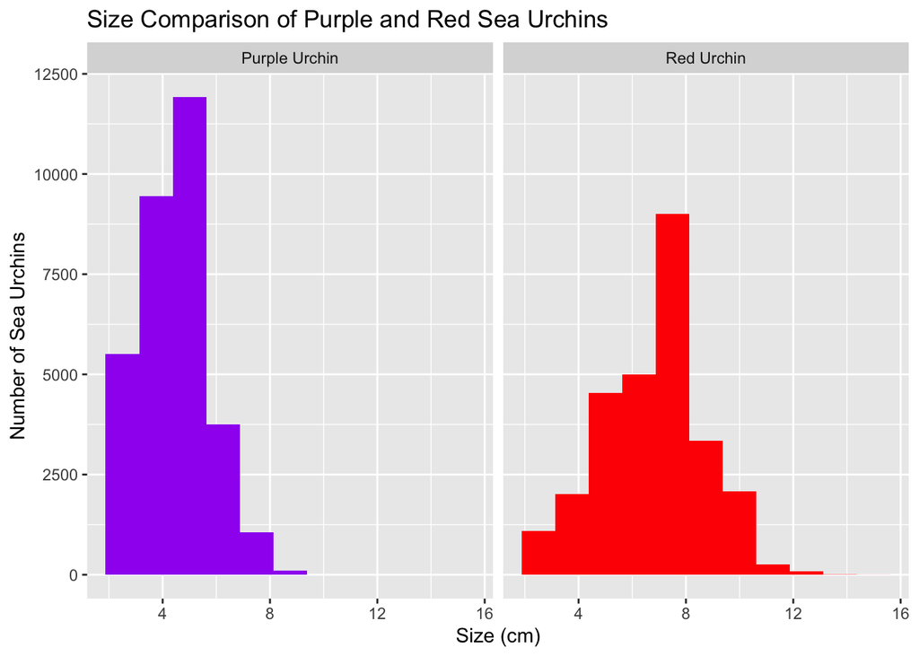

```r
### Plot it!
ggplot(urchins_clean,
       aes(x = size)) +
  geom_histogram(bins=11,
                 aes(fill = common_name),
          show.legend = FALSE ) +
  ### Make the graph faceted
  facet_wrap(~ common_name) +
    scale_fill_manual(values = c("purple", "red")) +
  labs(title = "Size Comparison of Purple and Red Sea Urchins", x = "Size (cm)", y = "Number of Sea Urchins")
```

#### Figure 1. Compares the distribution of sizes between purple and red urchins.

## Descriptive statistics table

### Create a finalized summary table that contains the following statistics for purple and red urchins.

```r
urchin_stats <- urchins_clean %>%
  group_by(common_name) %>%
  summarize(mean_size = round(mean(size), 2),
            sd_size = round(sd(size), 2),
            median_size = round(median(size), 2),
            sample_size = n())

urchin_stats %>%
  kable(col.names = c("Species",
                      "Mean Size (cm)",
                      "Standard Deviation (cm)",
                      "Median (cm)",
                      "Sample Size"),
        caption = "Table 1: Summary statistics comparing mean (cm), standard deviation (cm), median (cm), and sample sizes for purple and red urchins.") %>%

        kable_styling(full_width = FALSE)
```

Table 1: Summary statistics comparing mean (cm), standard deviation (cm), median (cm), and sample sizes for purple and red urchins.

| Species | Mean Size (cm) | Standard Deviation (cm) | Median (cm) | Sample Size |
| --- | --- | --- | --- | --- |
| Purple Urchin | 4.47 | 1.18 | 4.5 | 31805 |
| Red Urchin | 6.78 | 1.89 | 7.0 | 27408 |

# Section 2

## Explore purple urchin counts by site and year

```r
purple_urchins_ap <- urchins_clean %>%
  ### Filter to only include observations for purple urchins
  filter(common_name == "Purple Urchin") %>%
  ### Convert the date to class “Date”
   mutate(date = mdy(date)) %>%
  ### Create a new column that only contains the year
  mutate(year = year(date)) %>%
  ### Create a new column called site_full that contains the full name (not abbreviation) for each of the five sites
  mutate(site_full = case_when(
    site %in% c("NAPL") ~ "Naples Reef",
    site %in% c("AQUE") ~ "Arroyo Quemado Reef",
    site %in% c("CARP") ~ "Carpinteria Reef",
    site %in% c("MOHK") ~ "Mohawk Reef",
    site %in% c("IVEE") ~ "Isla Vista Reef"
  ))

### Write code to store a table containing the total number of purple urchins observed by site and year
total_purple <- purple_urchins_ap %>%
 group_by(site_full, year) %>%
  summarize( total_number = n())
```

## Data visualization

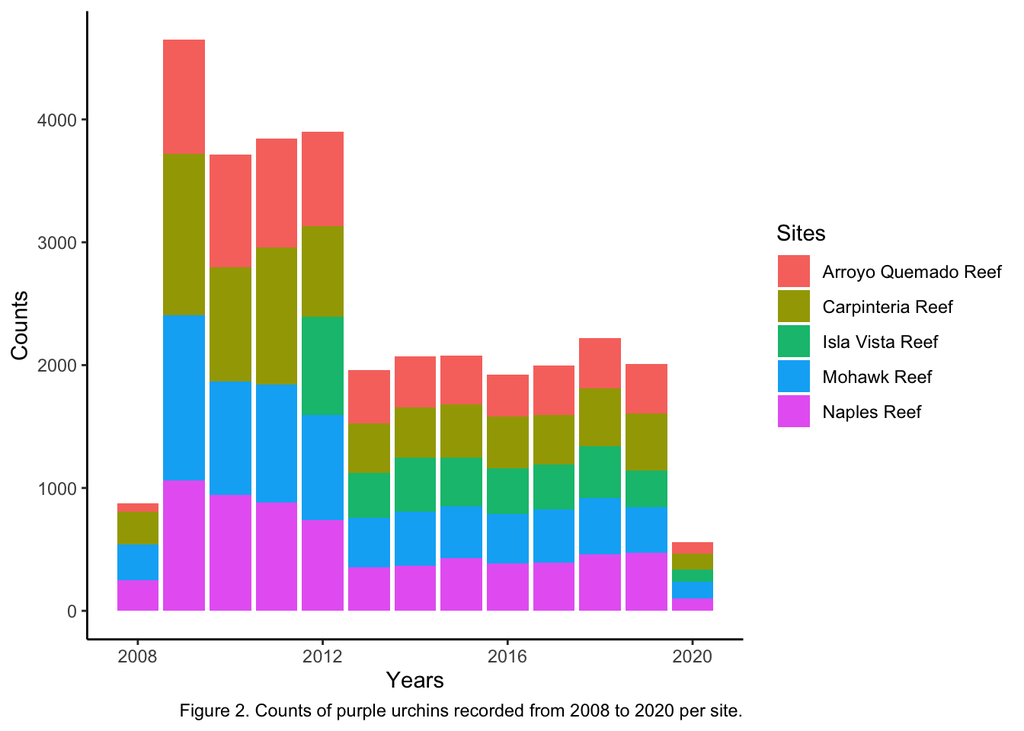

```r
ggplot(total_purple, aes(year, total_number)) +
  geom_col(aes(fill=site_full)) +
  theme_classic() +
  labs(x= "Years",
       y= "Counts",
       fill= "Sites",
       caption= "Figure 2. Counts of purple urchins recorded from 2008 to 2020 per site.")
```

## Data interpretation

### This graph shows counts of purple urchins recorded from 2008 to 2020 for five sties in Santa Barbara. The graph does not account for size, therefore, does not reflect actual changes in purple urchin populations. The experimental kelp treatments could explain the changes in number of purple urchins observed.